# Homework 3

Jake Mc Leroth

2025-03-28

Question 2:

```r
heart_data <- read.csv("/Users/jakemcleroth/Desktop/University/Masters/Modules/Semester 1/SLT/homework/hw_3/SAheart.csv")
heart_data <- heart_data[,c("chd","sbp", "tobacco", "ldl", "famhist", "obesity", "alcohol", "age")]
```

1. Exploratory Analysis

```r
colSums(is.na(heart_data))
```

```
##     chd     sbp tobacco     ldl famhist obesity alcohol     age
##       0       0       0       0       0       0       0       0
```

We see that the data set has no missing values.

Now we look at some visual plots of some descriptive statistics of each variable

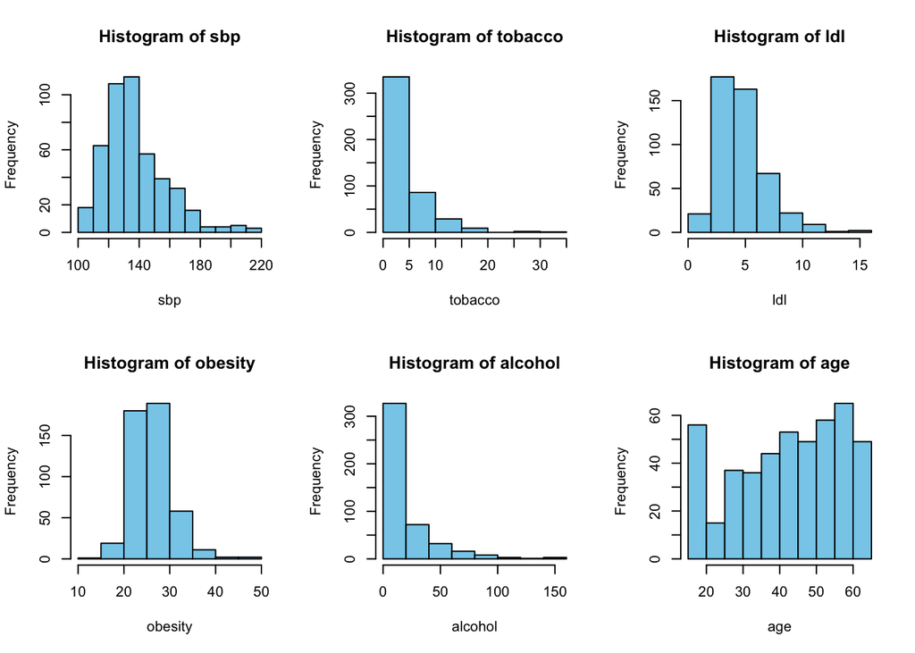

```r
# Histograms
par(mfrow = c(2, 3))  # Set up 2x3 plot grid
for (col in c("sbp", "tobacco", "ldl", "obesity", "alcohol", "age")) {
  hist(heart_data[[col]], main = paste("Histogram of", col), xlab = col, col = "skyblue")
}
```

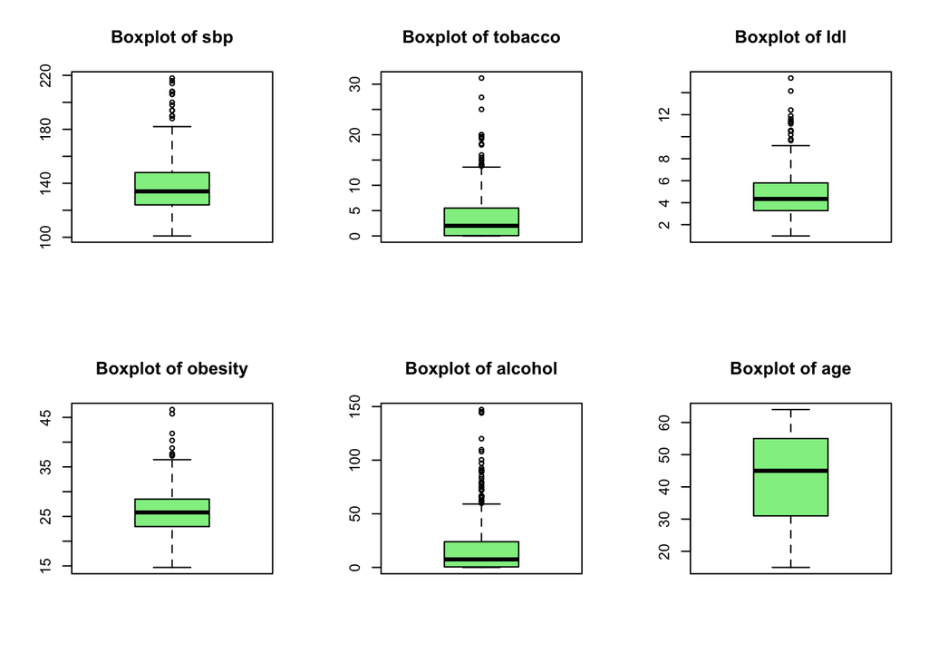

```r
# Boxplots
par(mfrow = c(2, 3))
for (col in c("sbp", "tobacco", "ldl", "obesity", "alcohol", "age")) {
  boxplot(heart_data[[col]], main = paste("Boxplot of", col), col = "lightgreen")
}
```

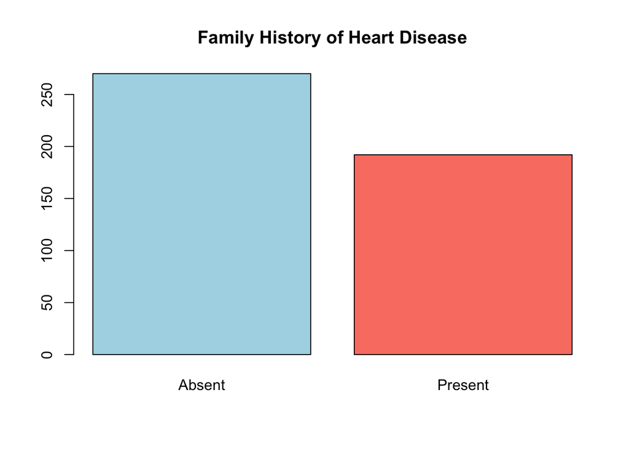

```r
barplot(table(heart_data$famhist),
        main = "Family History of Heart Disease",
        names.arg = c("Absent", "Present"),
        col = c("lightblue", "salmon"))
```

This class is fairly balanced.

2. Using red dots for cases of heart disease, and turqoise for not, we plot the scatter plot for all the predictor variables:

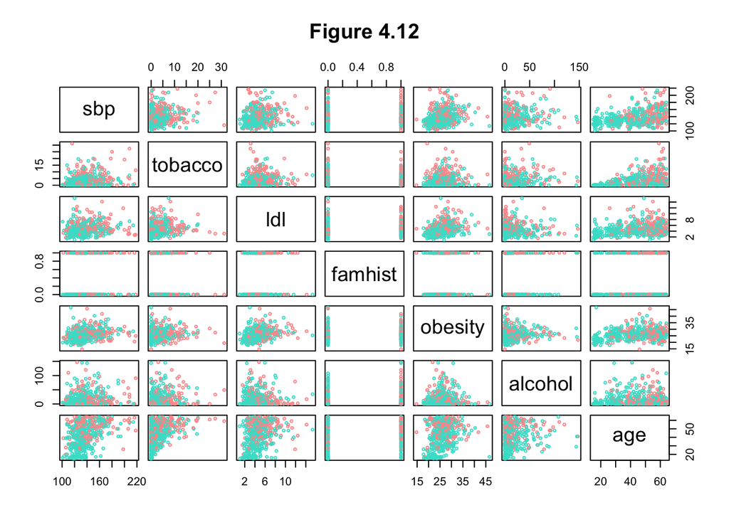

```r
numeric_heart_data <- heart_data[,-1]
numeric_heart_data$famhist <- ifelse(heart_data$famhist == "Present", 1, 0)

light_red <- "#FF9999" # Heart disease
turquoise_blue <- "#40E0D0" # No heart disease

point_colors <- ifelse(heart_data[,1] == 1, light_red, turquoise_blue)

pairs(numeric_heart_data,
      pch = 1,
      col = point_colors,
      cex = 0.5,
      lwd = 1,
      gap = 0.7,
      main = "Figure 4.12"
)
```

3. We replicate example 4.4.2. We start by fitting a logistic regression to the data:

```r
log_reg <- glm( chd ~ sbp + tobacco + ldl + famhist + obesity + alcohol + age, family = binomial, data = heart_data)

model_summary <- summary(log_reg)
results <- data.frame(
  Coefficient = model_summary$coefficients[, "Estimate"],
  Std_Error = model_summary$coefficients[, "Std. Error"],
  Z_Score = model_summary$coefficients[, "z value"],
  P_Value = model_summary$coefficients[, "Pr(>|z|)"]
)

print(round(results, 3), row.names = FALSE)
```

```
##  Coefficient Std_Error Z_Score P_Value
##       -4.130     0.964  -4.283   0.000
##        0.006     0.006   1.023   0.306
##        0.080     0.026   3.034   0.002
##        0.185     0.057   3.219   0.001
##        0.939     0.225   4.177   0.000
##       -0.035     0.029  -1.187   0.235
##        0.001     0.004   0.136   0.892
##        0.043     0.010   4.181   0.000
```

We see here that the values match that in table 4.2. We now want to do a stepwise logistic regression to get the best subset of predictors. We do this by dropping the least significant predictor and refiting the model, repeating until all predictors are significant. Alcohol is the least significant with a p-value of 0.892. We start by removing this for stepwise logistic regression:

```r
# remove alchohol
log_reg_2 <- glm( chd ~ sbp + tobacco + ldl + famhist + obesity + age, family = binomial, data = heart_data)

model_summary_2 <- summary(log_reg_2)
results_2 <- data.frame(
  Coefficient = model_summary_2$coefficients[, "Estimate"],
  Std_Error = model_summary_2$coefficients[, "Std. Error"],
  Z_Score = model_summary_2$coefficients[, "z value"],
  P_Value = model_summary_2$coefficients[, "Pr(>|z|)"]
)

print(round(results_2, 3), row.names = FALSE)
```

```
##  Coefficient Std_Error Z_Score P_Value
##       -4.128     0.964  -4.283   0.000
##        0.006     0.006   1.050   0.294
##        0.080     0.026   3.117   0.002
##        0.184     0.057   3.218   0.001
##        0.941     0.224   4.196   0.000
##       -0.035     0.029  -1.187   0.235
##        0.042     0.010   4.187   0.000
```

Next step we drop sbp:

```r
# remove sbp
log_reg_3 <- glm( chd ~ tobacco + ldl + famhist + obesity + age, family = binomial, data = heart_data)

model_summary_3 <- summary(log_reg_3)
results_3 <- data.frame(
  Coefficient = model_summary_3$coefficients[, "Estimate"],
  Std_Error = model_summary_3$coefficients[, "Std. Error"],
  Z_Score = model_summary_3$coefficients[, "z value"],
  P_Value = model_summary_3$coefficients[, "Pr(>|z|)"]
)

print(round(results_3, 3), row.names = FALSE)
```

```
##  Coefficient Std_Error Z_Score P_Value
##       -3.547     0.786  -4.511   0.000
##        0.081     0.026   3.154   0.002
##        0.185     0.057   3.238   0.001
##        0.933     0.224   4.169   0.000
##       -0.031     0.029  -1.063   0.288
##        0.045     0.010   4.630   0.000
```

Next we drop obesity:

```r
# remove sbp
log_reg_4 <- glm( chd ~ tobacco + ldl + famhist + age, family = binomial, data = heart_data)

model_summary_4 <- summary(log_reg_4)
results_4 <- data.frame(
  Coefficient = model_summary_4$coefficients[, "Estimate"],
  Std_Error = model_summary_4$coefficients[, "Std. Error"],
  Z_Score = model_summary_4$coefficients[, "z value"],
  P_Value = model_summary_4$coefficients[, "Pr(>|z|)"]
)

print(round(results_4, 3), row.names = FALSE)
```

```
##  Coefficient Std_Error Z_Score P_Value
##       -4.204     0.498  -8.437   0.000
##        0.081     0.026   3.163   0.002
##        0.168     0.054   3.093   0.002
##        0.924     0.223   4.141   0.000
##        0.044     0.010   4.521   0.000
```

We see that all predictors are significant at a 5% significance level. This is now the best subset of predictors from using stepwise logistic regression. We note that the output matches table 4.3.

4. We replicat figure 4.13, which shows the effect of L1 regularisation on predictor coefficients.

```r
library(glmnet)
```

```r
library(ggplot2)
```

To replicate 4.13, we first scale the predictor matrix and fit the lasso logistic regression:

```r
X <- as.matrix(numeric_heart_data)
X <- scale(X)
y <- heart_data[, 1]

lasso_model <- glmnet(X, y, alpha = 1, family = "binomial") # alpha=1 for L1 regularization
```

We then get. the data we are going to plot:

```r
coef_matrix <- coef(lasso_model, s = lasso_model$lambda)
coef_matrix <- coef_matrix[-1, ]
l1_norm <- colSums(abs(coef_matrix))

plot_data <- data.frame(
  Predictor = rep(rownames(coef_matrix), each = ncol(coef_matrix)),
  Lambda = rep(lasso_model$lambda, times = nrow(coef_matrix)),
  L1_Norm = rep(l1_norm, times = nrow(coef_matrix)),
  Coefficient = as.vector(t(coef_matrix))
)
```

Finally, we plot figure 4.13:

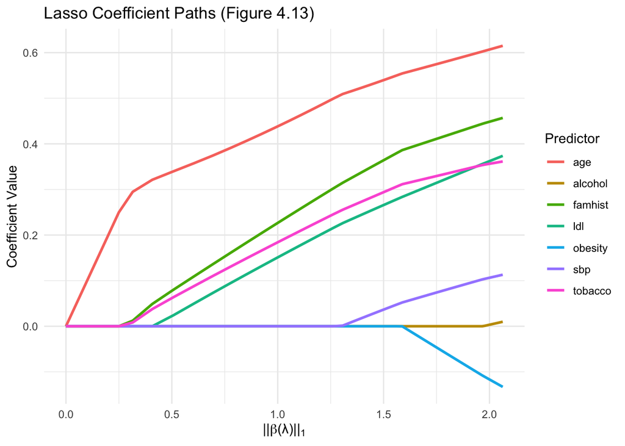

```r
ggplot(plot_data, aes(x = L1_Norm, y = Coefficient, color = Predictor)) +
  geom_line(linewidth = 1) +
  labs(
    x = expression(paste("||", beta, "(λ)||", ""[1])),
    y = "Coefficient Value",
    title = "Lasso Coefficient Paths (Figure 4.13)"
  ) +
  theme_minimal() +
  theme(legend.position = "right")
```

```r
library(dplyr)
```

5. Here we plot the calibration curve:

```r
# Get predicted probabilities for each model
heart_data$pred_probs_log_reg <- predict(log_reg, type = "response")
heart_data$pred_probs_log_reg_4 <- predict(log_reg_4, type = "response")
```

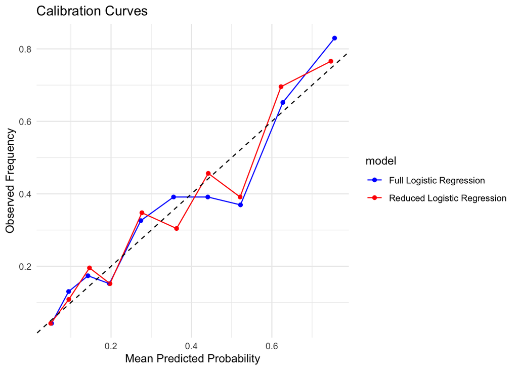

```r
num_bins <- 10

# Compute calibration curve
get_calibration_data <- function(pred_probs, outcome, bins = num_bins) {
  tibble(pred_probs = pred_probs, outcome = outcome) %>%
    mutate(bin = cut(pred_probs, breaks = quantile(pred_probs, probs = seq(0, 1, length.out = bins + 1), na.rm = TRUE), include.lowest = TRUE)) %>%
    group_by(bin) %>%
    summarise(mean_pred = mean(pred_probs, na.rm = TRUE),
              mean_obs = mean(outcome, na.rm = TRUE))
}

calibration_log_reg <- get_calibration_data(heart_data$pred_probs_log_reg, heart_data$chd)
calibration_log_reg_4 <- get_calibration_data(heart_data$pred_probs_log_reg_4, heart_data$chd)
calibration_log_reg$model <- "Full Logistic Regression"
calibration_log_reg_4$model <- "Reduced Logistic Regression"
calibration_data <- bind_rows(calibration_log_reg, calibration_log_reg_4)

ggplot(calibration_data, aes(x = mean_pred, y = mean_obs, color = model)) +
  geom_point() +
  geom_line() +
  geom_abline(slope = 1, intercept = 0, linetype = "dashed", color = "black") + #
  labs(x = "Mean Predicted Probability", y = "Observed Frequency", title = "Calibration Curves") +
  theme_minimal() +
  scale_color_manual(values = c("blue", "red"))
```

We see both plots are close to the 45 degree line, meaning they are both well calibrated. The red line seems to be closer most of the time, and therefore this is the better model when looking at in-sample data.